# Introduction

## Recap last session

- Types
- Operators
- User input
- Control flow
  - Conditional execution (if)
  - Repetitive execution (while, for)
- Sequence types: `list` `tuple` `dict`
- Character strings
- Dictionaries

## Questions & feedback

- Code structure --> separate session
- Choice of packages --> separate session  
  https://www.awesome-python.com
- Session format --> live coding
- Printing in Spyder

[figure not shown]

## Contents of this session

- Finishing up last session
  - Functions
  - Packages & modules
- What's missing?
- The numpy package
- The matplotlib package

Prerequisites: Python basics

Questions: please interrupt :-)

Format: live coding in Spyder  
Use Spyder or Jupyter Notebook

# Finishing up last session

- Functions
- Packages & modules

# What's missing?

## Exception handling

```python
try:
    x = 12 / 0
except ZeroDivisionError:
    print("Division by zero")
```

```
Division by zero
```

## Lambda expressions

```python
l1 = [1, 2, 3, 4, 5]
l2 = filter(lambda x: x > 2, l1)
l3 = map(lambda x: x ** 2, l2)
print(list(l3))
```

```
[9, 16, 25]
```

## List comprehension

```python
l1 = [1, 2, 3, 4, 5]
l2 = [x ** 2 for x in l1 if x > 2]
print(l2)
```

```
[9, 16, 25]
```

## Object-oriented programming

```python
# Object-oriented programming

class Dog:
    species = "mammal"

    def __init__(self, name):
        self.name = name

    def __str__(self):
        return self.name + " the Dog"

    def bark(self):
        print(self.name, "barks")

fluffy = Dog("Fluffy")
print(fluffy)
fluffy.bark()

pavlov = Dog("Pavlov")
print(pavlov)
pavlov.bark()
```

```
Fluffy the Dog
Fluffy barks
Pavlov the Dog
Pavlov barks
```

## And (not) much more...

Iterators, generators, context managers, concurrent/asynchronous execution, ...

## The scipy universe

https://www.scipy.org

Python-based ecosystem of open-source software for mathematics, science, and engineering

- **NumPy: Base N-dimensional array package**
- SciPy library: Fundamental library for scientific computing
- **Matplotlib: Comprehensive 2-D plotting**
- *IPython: Enhanced interactive console*
- SymPy: Symbolic mathematics
- **pandas: Data structures & analysis**

# The numpy package

Copied from https://numpy.org:

> NumPy is the fundamental package for scientific computing with Python. It contains among other things:
> - a powerful N-dimensional array object
> - sophisticated (broadcasting) functions
> - tools for integrating C/C++ and Fortran code
> - useful linear algebra, Fourier transform, and random number capabilities

Using NumPy in Python gives functionality comparable to MATLAB, see [Numpy for Matlab users](https://docs.scipy.org/doc/numpy/user/numpy-for-matlab-users.html). The numpy package comes pre-installed with Anaconda for Python 3.7.

Numpy reference: https://docs.scipy.org/doc/numpy/reference/

```python
import numpy as np  # by convention, the numpy package is imported as np
```

## Numpy arrays

For readability purposes, numpy arrays are called *arrays* from here on.

```python
a = np.array([1, 2, 3, 4])  # convert list to array
print(a)
```

```
[1 2 3 4]
```

```python
a[3] = 6
print(a[3])
```

```
6
```

```python
print(len(a))  # the lenght of numpy arrays is fixed!
```

```
4
```

### Shape

Numpy arrays have a fixed shape, determining the size of each dimension.

```python
a = np.array([[0, 1, 2], [3, 4, 5]])  # convert list of lists to 2D array
print(a)
```

```
[[0 1 2]
 [3 4 5]]
```

```python
print(a.shape)  # 2D shapes are interpreted as (rows, cols) only when printing!
```

```
(2, 3)
```

```python
a = np.array([[0, 1, 2], [3, 4]])  # sublists of different lengths --> 1D array
print(a)
```

```
[list([0, 1, 2]) list([3, 4])]
```

```python
print(a.shape)
```

```
(2,)
```

### Data type

NumPy supports a [much greater variety of numerical types](https://numpy.org/doc/1.18/user/basics.types.html) than Python does natively. Numpy data types are closely related to C data types, as numpy is implemented in C.

Primitive data types (e.g. `np.int_` `np.double`) and fixed-sized aliases (e.g. `np.int64` `np.float64`) exist.

All elements within a numpy array have the same numpy data type.

```python
a = np.array([1, 2, 3, 4])
print(type(a))
print(a.dtype)
```

```
<class 'numpy.ndarray'>
int64
```

```python
a = np.array([1, 2.5, 3, 4.5])  # ints will be converted to floats
print(type(a))
print(a.dtype)
```

```
<class 'numpy.ndarray'>
float64
```

## Array creation

```python
a = np.array([[0, 1, 2], [3, 4, 5]], dtype=np.float64)
print(a)
```

```
[[0. 1. 2.]
 [3. 4. 5.]]
```

```python
a = np.empty((800, 600))  # not initialized!
print(a)
```

```
[[0. 0. 0. ... 0. 0. 0.]
 [0. 0. 0. ... 0. 0. 0.]
 [0. 0. 0. ... 0. 0. 0.]
 ...
 [0. 0. 0. ... 0. 0. 0.]
 [0. 0. 0. ... 0. 0. 0.]
 [0. 0. 0. ... 0. 0. 0.]]
```

```python
a = np.zeros((800, 600))
print(a)
```

```
[[0. 0. 0. ... 0. 0. 0.]
 [0. 0. 0. ... 0. 0. 0.]
 [0. 0. 0. ... 0. 0. 0.]
 ...
 [0. 0. 0. ... 0. 0. 0.]
 [0. 0. 0. ... 0. 0. 0.]
 [0. 0. 0. ... 0. 0. 0.]]
```

```python
a = np.ones((800, 600))
print(a)
```

```
[[1. 1. 1. ... 1. 1. 1.]
 [1. 1. 1. ... 1. 1. 1.]
 [1. 1. 1. ... 1. 1. 1.]
 ...
 [1. 1. 1. ... 1. 1. 1.]
 [1. 1. 1. ... 1. 1. 1.]
 [1. 1. 1. ... 1. 1. 1.]]
```

```python
a = np.full((800, 600), 7)
print(a)
```

```
[[7 7 7 ... 7 7 7]
 [7 7 7 ... 7 7 7]
 [7 7 7 ... 7 7 7]
 ...
 [7 7 7 ... 7 7 7]
 [7 7 7 ... 7 7 7]
 [7 7 7 ... 7 7 7]]
```

```python
a = np.arange(0, 100, 3)  # numbers in the range [0, 100) with step size 3
print(a)
```

```
[ 0  3  6  9 12 15 18 21 24 27 30 33 36 39 42 45 48 51 54 57 60 63 66 69
 72 75 78 81 84 87 90 93 96 99]
```

```python
a = np.linspace(0, 100, 3)  # 3 numbers in the range [0, 100]
print(a)
```

```
[  0.  50. 100.]
```

## Array indexing

```python
a = np.arange(0, 50)
print(a)
```

```
[ 0  1  2  3  4  5  6  7  8  9 10 11 12 13 14 15 16 17 18 19 20 21 22 23
 24 25 26 27 28 29 30 31 32 33 34 35 36 37 38 39 40 41 42 43 44 45 46 47
 48 49]
```

```python
a.shape = (5, 10)  # reshape the array to two dimensions
print(a)
```

```
[[ 0  1  2  3  4  5  6  7  8  9]
 [10 11 12 13 14 15 16 17 18 19]
 [20 21 22 23 24 25 26 27 28 29]
 [30 31 32 33 34 35 36 37 38 39]
 [40 41 42 43 44 45 46 47 48 49]]
```

```python
print(a[1, 2])  # cf. list of lists: a[1][2]
```

```
12
```

```python
print('first row:', a[0, :])
print('first column:', a[:, 0])
```

```
first row: [0 1 2 3 4 5 6 7 8 9]
first column: [ 0 10 20 30 40]
```

```python
central_elements = a[1:-1, 1:-1]
print(central_elements)
```

```
[[11 12 13 14 15 16 17 18]
 [21 22 23 24 25 26 27 28]
 [31 32 33 34 35 36 37 38]]
```

```python
row_indices = [0, 2, 4]
print(a[row_indices, :])
```

```
[[ 0  1  2  3  4  5  6  7  8  9]
 [20 21 22 23 24 25 26 27 28 29]
 [40 41 42 43 44 45 46 47 48 49]]
```

```python
mask = np.ones(a.shape, dtype=np.bool_)  # note the np.bool_ data type
mask[::2, 1::2] = False  # every 2nd row, every 2nd col starting from index 1
print(mask)
```

```
[[ True False  True False  True False  True False  True False]
 [ True  True  True  True  True  True  True  True  True  True]
 [ True False  True False  True False  True False  True False]
 [ True  True  True  True  True  True  True  True  True  True]
 [ True False  True False  True False  True False  True False]]
```

```python
print(a[mask])
```

```
[ 0  2  4  6  8 10 11 12 13 14 15 16 17 18 19 20 22 24 26 28 30 31 32 33
 34 35 36 37 38 39 40 42 44 46 48]
```

```python
a[mask] = 0
print(a)
```

```
[[ 0  1  0  3  0  5  0  7  0  9]
 [ 0  0  0  0  0  0  0  0  0  0]
 [ 0 21  0 23  0 25  0 27  0 29]
 [ 0  0  0  0  0  0  0  0  0  0]
 [ 0 41  0 43  0 45  0 47  0 49]]
```

```python
a[0:3, 0:3] = np.ones((3, 3))
print(a)
```

```
[[ 1  1  1  3  0  5  0  7  0  9]
 [ 1  1  1  0  0  0  0  0  0  0]
 [ 1  1  1 23  0 25  0 27  0 29]
 [ 0  0  0  0  0  0  0  0  0  0]
 [ 0 41  0 43  0 45  0 47  0 49]]
```

## numpy.random

Contains function for random sampling from various distributions

Good quick introduction: https://cs231n.github.io/python-numpy-tutorial/

https://numpy.org/doc/1.18/reference/random/generator.html

There exists a similar, but independent `random` module in the Python Standard Library.

```python
from numpy.random import default_rng

rng = default_rng(seed=123)  # only sets the seed of rng!

a = rng.normal(size=(10, 5))
print(a)
```

```
[[-0.98912135 -0.36778665  1.28792526  0.19397442  0.9202309 ]
 [ 0.57710379 -0.63646365  0.54195222 -0.31659545 -0.32238912]
 [ 0.09716732 -1.52593041  1.1921661  -0.67108968  1.00026942]
 [ 0.13632112  1.53203308 -0.65996941 -0.31179486  0.33776913]
 [-2.2074711   0.82792144  1.54163039  1.12680679  0.75476964]
 [-0.14597789  1.28190223  1.07403062  0.39262084  0.00511431]
 [-0.36176687 -1.2302322   1.22622929 -2.17204389 -0.37014735]
 [ 0.16438007  0.85988118  1.76166124  0.99332378 -0.29152143]
 [ 0.72812756 -1.26160032  1.42993853 -0.15647532 -0.67375915]
 [-0.6390601  -0.06136133 -0.39278492  2.28990995 -0.71818115]]
```

```python
# Legacy code - don't do this anymore (worse statistical properties!)

from numpy import random  # can be confused with the PSL random module!

random.seed(123)

a = random.normal(size=(10, 5))
print(a)
```

```
[[-1.0856306   0.99734545  0.2829785  -1.50629471 -0.57860025]
 [ 1.65143654 -2.42667924 -0.42891263  1.26593626 -0.8667404 ]
 [-0.67888615 -0.09470897  1.49138963 -0.638902   -0.44398196]
 [-0.43435128  2.20593008  2.18678609  1.0040539   0.3861864 ]
 [ 0.73736858  1.49073203 -0.93583387  1.17582904 -1.25388067]
 [-0.6377515   0.9071052  -1.4286807  -0.14006872 -0.8617549 ]
 [-0.25561937 -2.79858911 -1.7715331  -0.69987723  0.92746243]
 [-0.17363568  0.00284592  0.68822271 -0.87953634  0.28362732]
 [-0.80536652 -1.72766949 -0.39089979  0.57380586  0.33858905]
 [-0.01183049  2.39236527  0.41291216  0.97873601  2.23814334]]
```

## Basic operations

Arithmetic operators on arrays apply **elementwise**!

```python
rng = default_rng(seed=123)

a = rng.normal(size=(4, 3))
b = rng.normal(size=(4, 3))
print(a)
print(b)
```

```
[[-0.98912135 -0.36778665  1.28792526]
 [ 0.19397442  0.9202309   0.57710379]
 [-0.63646365  0.54195222 -0.31659545]
 [-0.32238912  0.09716732 -1.52593041]]
[[ 1.1921661  -0.67108968  1.00026942]
 [ 0.13632112  1.53203308 -0.65996941]
 [-0.31179486  0.33776913 -2.2074711 ]
 [ 0.82792144  1.54163039  1.12680679]]
```

```python
print(a + 2)  # broadcasts 2 ("adds two to every element") --> retains shape
```

```
[[1.01087865 1.63221335 3.28792526]
 [2.19397442 2.9202309  2.57710379]
 [1.36353635 2.54195222 1.68340455]
 [1.67761088 2.09716732 0.47406959]]
```

```python
print(a ** b)  # shapes of a and b need to be compatible (broadcastable)
```

```
[[       nan        nan 1.28801306]
 [0.79965844 0.88041761 1.43735851]
 [       nan 0.81309303        nan]
 [       nan 0.02748719        nan]]
```

```python
# broadcasting: https://docs.scipy.org/doc/numpy/user/basics.broadcasting.html

row_factors = np.array([1, 2, 3, 4])
col_factors = np.array([10, 20, 30])

# multiply every column (match shapes starting from the innermost dimension)
print(a * col_factors)

# multiply every row (None introduces "fake" column dimension of size 1)
print(a * row_factors[:, None])
```

```
[[ -9.8912135   -7.35573303  38.63775784]
 [  1.93974419  18.40461799  17.31311374]
 [ -6.36463646  10.83904441  -9.49786353]
 [ -3.22389116   1.94334637 -45.7779122 ]]
[[-0.98912135 -0.36778665  1.28792526]
 [ 0.38794884  1.8404618   1.15420758]
 [-1.90939094  1.62585666 -0.94978635]
 [-1.28955646  0.38866927 -6.10372163]]
```

```python
print(a * b)  # elementwise product!

b_transposed = b.T
print(a @ b.T)  # new operator: matrix product, alternative: a.dot(b)
```

```
[[-1.17919695  0.24681782  1.28827225]
 [ 0.02644281  1.40982418 -0.38087085]
 [ 0.19844609  0.18305473  0.69887531]
 [-0.26691286  0.14979609 -1.71942875]]
[[ 0.35589313 -1.54829073 -2.65888182  0.06533708]
 [ 0.19095155  1.05539614 -1.02359458  2.22953598]
 [-1.43914967  0.9524686   1.08037613 -0.04819379]
 [-1.97589088  1.1119825   3.50178666 -1.83654552]]
```

```python
print(np.sum(a))
print(np.exp(a))
print(np.log(a))
# ... many more
```

```
-0.5399327116307213
[[0.37190332 0.69226486 3.62525729]
 [1.21406523 2.50986985 1.78087317]
 [0.52916042 1.71936016 0.72862546]
 [0.72441625 1.10204475 0.21741867]]
[[        nan         nan  0.2530326 ]
 [-1.64002899 -0.08313066 -0.54973315]
 [        nan -0.61257744         nan]
 [        nan -2.33132085         nan]]
```

```python
print(a > 0)  # elementwise comparisons yield boolean masks
```

```
[[False False  True]
 [ True  True  True]
 [False  True False]
 [False  True False]]
```

```python
print(a[a > 0])
```

```
[1.28792526 0.19397442 0.9202309  0.57710379 0.54195222 0.09716732]
```

## Concluding remarks

Arrays can be n-dimensional, not just 1D or 2D

Why use numpy arrays?

- Much faster (vectorization)
- Much more memory efficient (fixed shape & data type)
- Basic operations provided by the numpy package

Numpy replacement for deep learning/GPUs: [PyTorch](https://pytorch.org)

Copies versus views:  
https://docs.scipy.org/doc/numpy/user/quickstart.html#copies-and-views

```python
a = np.arange(12)
print(a.shape)
b = a  # no new object is created!
b.shape = (3, 4)  # changes the shape of a
print(a.shape)
```

```
(12,)
(3, 4)
```

```python
a = np.arange(12)
print(a.shape)
b = a[:]  # indexing always returns a new array
b.shape = (3, 4)  # does not change the shape of a
print(a.shape)
```

```
(12,)
(12,)
```

# The matplotlib package

Matplotlib is a comprehensive library for creating visualizations in Python.

**Online resources**:

- [Gallery](https://matplotlib.org/gallery/)
- [Tutorials](https://matplotlib.org/tutorials/)
- [Documentation](https://matplotlib.org/api/) (advice: use google for searching docs)

**Disclaimer**: `matplotlib` is a very capable package, but [has problems](https://phillipmfeldman.org/Python/Python_Limitations.html).

- Lack of uniformity among the interfaces to the various functions and methods
- The interface puts too much burden on the programmer's memory/reference
- Default values are often not sensible - pretty plots tend to require fiddling

Nevertheless, `matplotlib` is the most widely used Python plotting library.

## Potential alternatives

Potentially covered in future sessions

- [plotnine](https://plotnine.readthedocs.io): a grammar of graphics for Python, almost identical to ggplot2
- [seaborn](https://seaborn.pydata.org): easy-to-use extension of `matplotlib` providing pretty defaults
- [bokeh](https://bokeh.org) or [plotly/dash](https://plotly.com/dash) for interactive visualization
- [altair](https://altair-viz.github.io)

## Importing matplotlib

```python
import matplotlib.pyplot as plt  # by convention, the pyplot interface is imported as plt

from numpy.random import default_rng

rng = default_rng()
```

## Anotomy of a figure

Source: https://matplotlib.org/3.1.0/gallery/showcase/anatomy.html

[figure not shown]

## Simple histograms

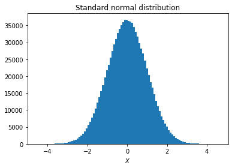

```python
x = rng.normal(size=10 ** 6)

plt.hist(x, bins=100)
plt.title('Standard normal distribution')
plt.xlabel('$X$')  # note: LaTeX can be used with dollar signs
plt.show()  # everything until here is plotted in the same figure
```

## Simple line charts

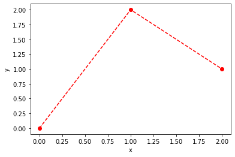

```python
# note: data points are matched by position in lists
x = [0, 1, 2]
y = [0, 2, 1]

plt.plot(x, y, 'ro--')  # r: red, o: points, --: dashed line
plt.xlabel('x')
plt.ylabel('y')
plt.show()
```

## Multi-panel figures

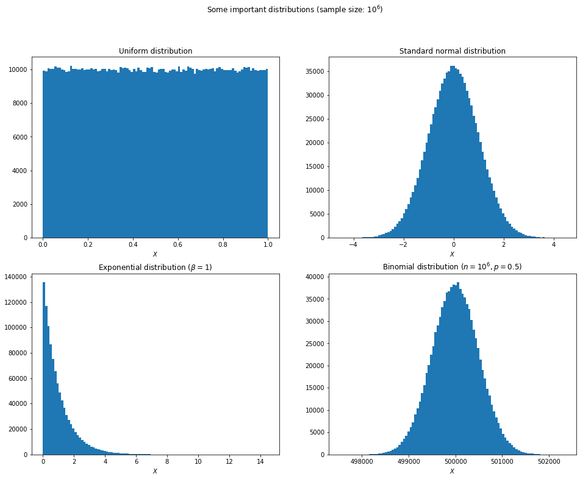

```python
fig, axs = plt.subplots(nrows=2, ncols=2, figsize=(16, 12))

x = rng.uniform(size=10 ** 6)
axs[0, 0].hist(x, bins=100)
axs[0, 0].set_title('Uniform distribution')
axs[0, 0].set_xlabel('$X$')

x = rng.normal(size=10 ** 6)
axs[0, 1].hist(x, bins=100)
axs[0, 1].set_title('Standard normal distribution')
axs[0, 1].set_xlabel('$X$')

x = rng.exponential(size=10 ** 6)
axs[1, 0].hist(x, bins=100)
axs[1, 0].set_title(r'Exponential distribution ($\beta = 1$)')
axs[1, 0].set_xlabel('$X$')

x = rng.binomial(10 ** 6, 0.5, size=10 ** 6)
axs[1, 1].hist(x, bins=100)
axs[1, 1].set_title(r'Binomial distribution ($n = 10^6, p = 0.5$)')
axs[1, 1].set_xlabel('$X$')

plt.suptitle('Some important distributions (sample size: $10^6$)')
plt.show()
```

## Trivia

### XKCD

`plt.xkcd()` turns on xkcd sketch-style drawing mode.  
https://matplotlib.org/gallery/showcase/xkcd.html

[figure not shown]

### Mandelbrot

https://matplotlib.org/examples/showcase/mandelbrot.html

> The *Mandelbrot set* is the set of complex numbers $c$ for which the function $f_c(z)=z^2+c$ does not diverge when iterated from $z=0$, i.e., for which the sequence $f_c(0)$, $f_c(f_c(0))$, etc., remains bounded in absolute value.

[figure not shown]

# Practice material

This session: slides & video recording

BIO134 Open edX course: Python for Biologists; weeks 1-12

Online Python challenge platforms, e.g. https://edabit.com/challenges/python3

Online book for reference: http://openbookproject.net/thinkcs/python/english3e

Numpy exercises: https://www.w3resource.com/python-exercises/numpy/  
Matplotlib exercises: https://www.w3resource.com/graphics/matplotlib/

# Outlook

Next Python session: tabular data with `pandas` and image processing

Potential future topics:

- Code organization
- Version control (Git)
- Documentation & testing
- Package management & dockerization
- Integrated development environments
- Pipeline building with `nextflow` `snakemake` `luigi` ...
- Relational databases with `sqlalchemy`
- Machine learning with `scikit-learn`
- Deep learning with `pytorch`
- GUI development with `pyqt`
- ...